Tarea 6 - Relaciones entre Variables Cualitativo y uno cuantitativo

Por: César Omar López Arteaga

Marzo 2024

# Pregunta 1

Bajar el archivo Clase_6.R

Se descargara el archivo Iris.csv a una carpeta local, luego se cargara el archivo y se muestrara la estructura de la data, luego se muestra la tabla

```r
# Carga de la data Iris
iris<- read.csv("G:/R IMCA/TAREA 6/DESCARGA_DATA/Iris.csv",header=TRUE,row.names=1)

# Verificar la estructura de los datos
str(iris)
```

```
## 'data.frame':    150 obs. of  5 variables:
##  $ Sepal.length: num  5.1 4.9 4.7 4.6 5 5.4 4.6 5 4.4 4.9 ...
##  $ Sepal.width : num  3.5 3 3.2 3.1 3.6 3.9 3.4 3.4 2.9 3.1 ...
##  $ Petal.length: num  1.4 1.4 1.3 1.5 1.4 1.7 1.4 1.5 1.4 1.5 ...
##  $ Petal.width : num  0.2 0.2 0.2 0.2 0.2 0.4 0.3 0.2 0.2 0.1 ...
##  $ Species     : chr  "setosa" "setosa" "setosa" "setosa" ...
```

```r
# Visualizar los primeros registros de los datos sin modificar
head(iris,n=10)
```

|  | Sepal.length | Sepal.width | Petal.length | Petal.width | Species |
| --- | --- | --- | --- | --- | --- |
| 1 | 5.1 | 3.5 | 1.4 | 0.2 | setosa |
| 2 | 4.9 | 3.0 | 1.4 | 0.2 | setosa |
| 3 | 4.7 | 3.2 | 1.3 | 0.2 | setosa |
| 4 | 4.6 | 3.1 | 1.5 | 0.2 | setosa |
| 5 | 5.0 | 3.6 | 1.4 | 0.2 | setosa |
| 6 | 5.4 | 3.9 | 1.7 | 0.4 | setosa |
| 7 | 4.6 | 3.4 | 1.4 | 0.3 | setosa |
| 8 | 5.0 | 3.4 | 1.5 | 0.2 | setosa |
| 9 | 4.4 | 2.9 | 1.4 | 0.2 | setosa |
| 10 | 4.9 | 3.1 | 1.5 | 0.1 | setosa |

```r
#Total de observaciones de la variable 1
n_t = length(iris[,1])

#Media de las observaciones de la variable 1
m_t = mean(iris[,1])

#Varianza de las observaciones de la variable 1
v_t = var(iris[,1])*(n_t-1)/n_t

#Desviacon Standar de las observaciones de la variable 1
s_t = sqrt(v_t)

#Coeficiente de variacion de las observaciones de la variable 1
cvt = s_t/m_t

#Agrupamiento de las estadisticas totales
total=rbind(n_t,m_t,v_t,s_t,cvt)

#Estadisticas por varible categorica (Variable 5)
n_unit=table(iris[,5])

#MEdia por categorica (Variable 5)
mean=tapply(iris[,1],iris[,5],mean)

#Varianza por categorica (Variable 5)
var=tapply(iris[,1],iris[,5],var)
var=var*(n_unit-1)/n_unit

#Desviacion Standar por categorica (Variable 5)
stdev=sqrt(var)
cv=stdev/mean

#Agrupamiento de las estadisticas parciales por variable categorica
brk=rbind(n_unit,mean,var,stdev,cv)

#Agrupamiento de la estadisticas por categoria (Var 5) contra la estadistica global(var 1)
brtot=cbind(brk,total)
colnames(brtot) = c(colnames(brk),"total")
brtot
```

```
##             setosa versicolor  virginica       total
## n_unit 50.00000000 50.0000000 50.0000000 150.0000000
## mean    5.00600000  5.9360000  6.5880000   5.8433333
## var     0.12176400  0.2611040  0.3962560   0.6811222
## stdev   0.34894699  0.5109834  0.6294887   0.8253013
## cv      0.06970575  0.0860821  0.0955508   0.1412381
```

```r
#La razón de correlación se puede calcular en dos maneras bajo esta tabla
e = sum(n_unit*(mean-m_t)^2) / (n_t*v_t) ; e
```

```
## [1] 0.6187057
```

```r
e = (n_t*v_t-sum(n_unit*var))/(n_t*v_t) ; e
```

```
## [1] 0.6187057
```

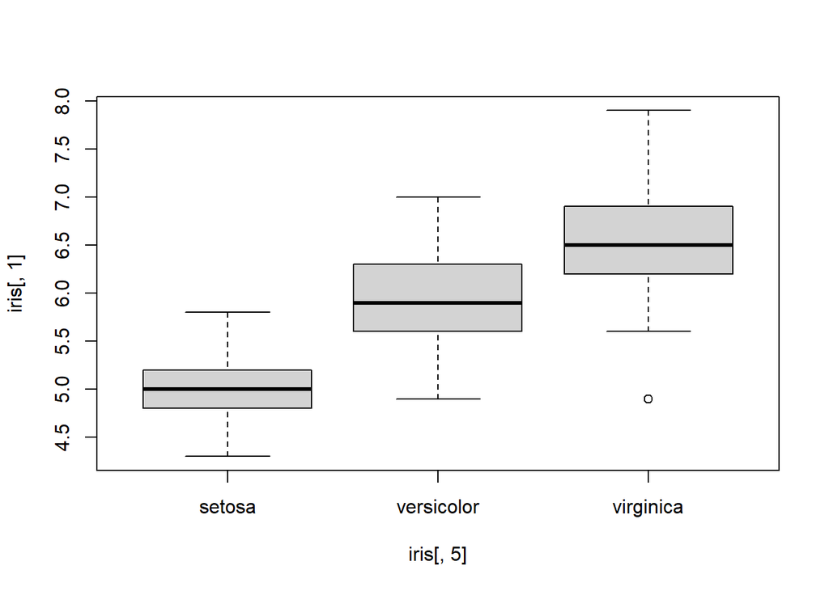

```r
boxplot(iris[,1]~iris[,5])
```

```r
#calcular la covarianza entre dos caracteres x y y,
cov(iris[,2],iris[,1])
```

```
## [1] -0.042434
```

```r
#covarianza de toda la tabla, cruzando variable sin modificacion
cov(iris[,1:4])
```

```
##              Sepal.length Sepal.width Petal.length Petal.width
## Sepal.length    0.6856935  -0.0424340    1.2743154   0.5162707
## Sepal.width    -0.0424340   0.1899794   -0.3296564  -0.1216394
## Petal.length    1.2743154  -0.3296564    3.1162779   1.2956094
## Petal.width     0.5162707  -0.1216394    1.2956094   0.5810063
```

```r
#covarianza de toda la tabla, cruzando variable CON modificacion
cov(iris[,1:4])*(n_t-1)/n_t
```

```
##              Sepal.length Sepal.width Petal.length Petal.width
## Sepal.length   0.68112222 -0.04215111    1.2658200   0.5128289
## Sepal.width   -0.04215111  0.18871289   -0.3274587  -0.1208284
## Petal.length   1.26582000 -0.32745867    3.0955027   1.2869720
## Petal.width    0.51282889 -0.12082844    1.2869720   0.5771329
```

```r
#Calculo de correlacion de dos variables
cor(iris[,1],iris[,4])
```

```
## [1] 0.8179411
```

```r
#Calculo de correlacion de toda la tabla, cruzando variables
cor(iris[,1:4])
```

```
##              Sepal.length Sepal.width Petal.length Petal.width
## Sepal.length    1.0000000  -0.1175698    0.8717538   0.8179411
## Sepal.width    -0.1175698   1.0000000   -0.4284401  -0.3661259
## Petal.length    0.8717538  -0.4284401    1.0000000   0.9628654
## Petal.width     0.8179411  -0.3661259    0.9628654   1.0000000
```

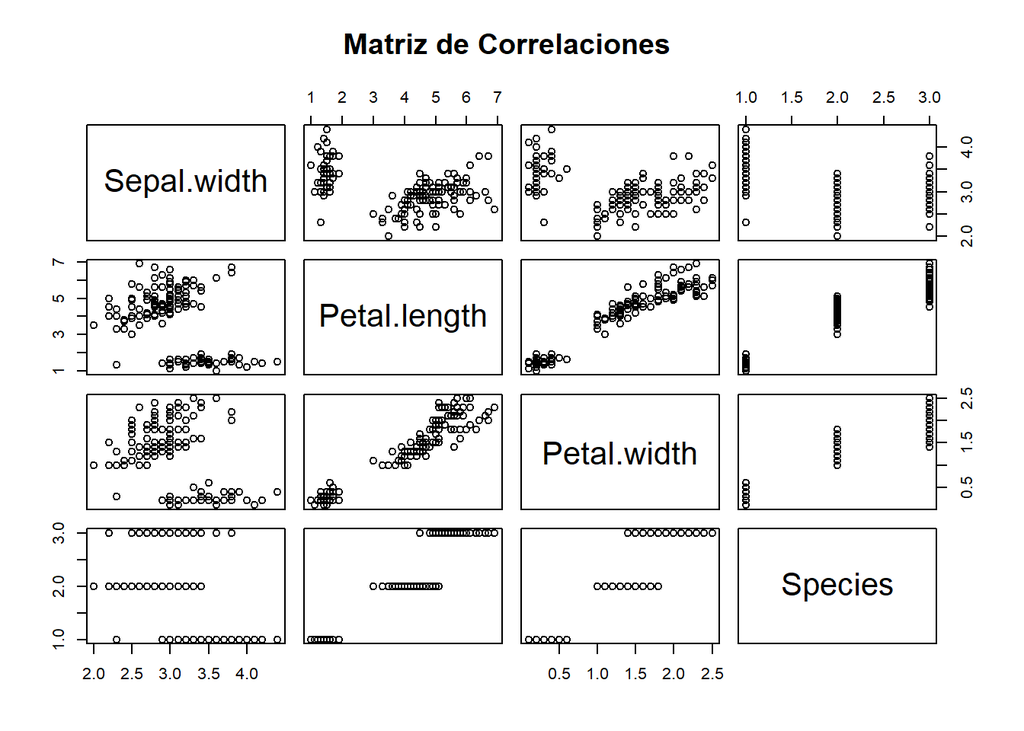

```r
#Matriz de Correlaciones total
plot(iris[,2:5], main="Matriz de Correlaciones ")
```

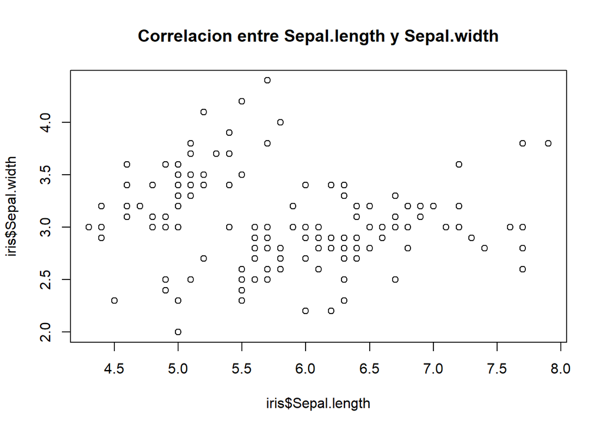

```r
#Correlacion entre Sepal.length y iris$Sepal.width
plot(iris$Sepal.length,iris$Sepal.width,main="Correlacion entre Sepal.length y Sepal.width")
```

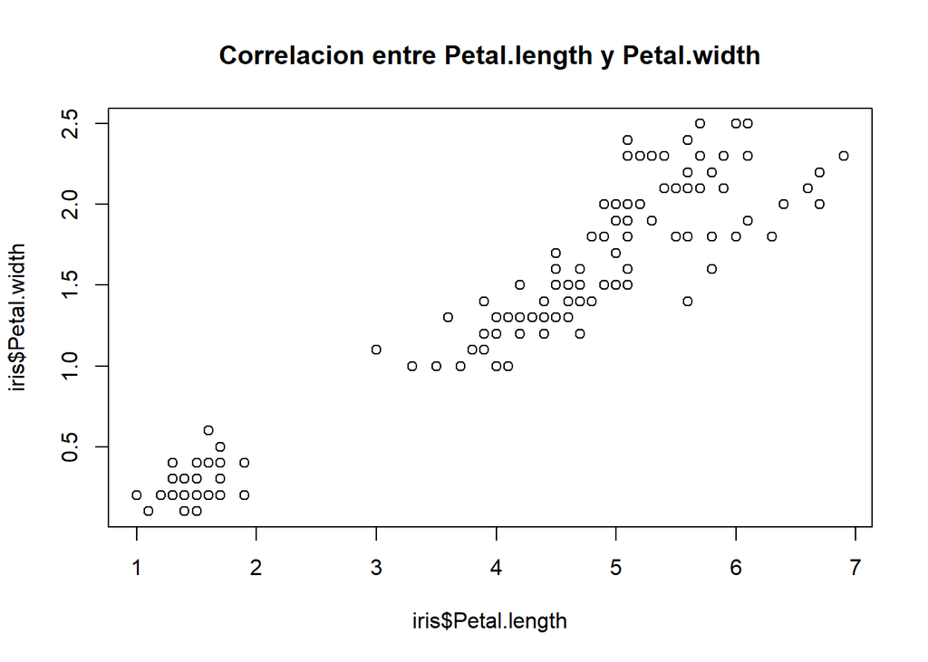

```r
#Correlacion entre Petal.length y Petal.width
plot(iris$Petal.length,iris$Petal.width,main="Correlacion entre Petal.length y Petal.width")
```

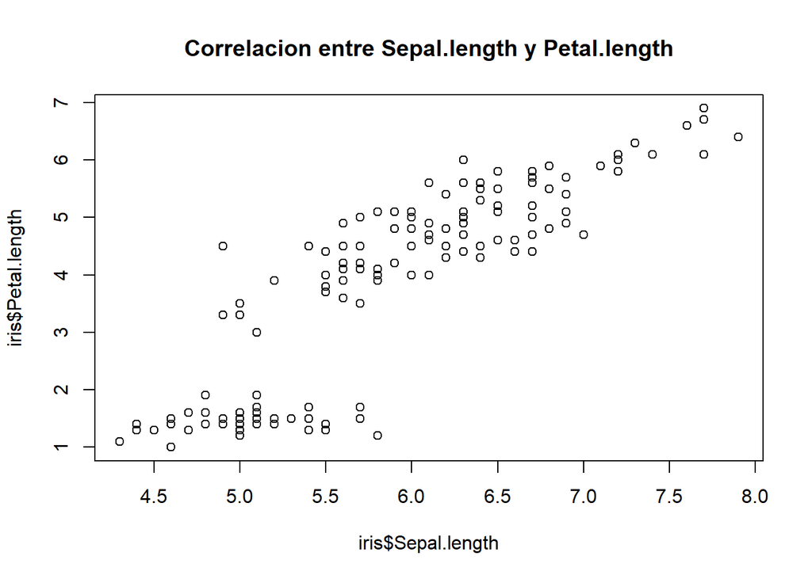

```r
#Correlacion entre Sepal.length y iris$Sepal.width
plot(iris$Sepal.length,iris$Petal.length,main="Correlacion entre Sepal.length y Petal.length")
```

```r
#Coreelacion Sperman
cor(iris[,1:4],method="spearman")
```

```
##              Sepal.length Sepal.width Petal.length Petal.width
## Sepal.length    1.0000000  -0.1667777    0.8818981   0.8342888
## Sepal.width    -0.1667777   1.0000000   -0.3096351  -0.2890317
## Petal.length    0.8818981  -0.3096351    1.0000000   0.9376668
## Petal.width     0.8342888  -0.2890317    0.9376668   1.0000000
```

De matrix de correlaciones observamos que entre las variables Sepal.length y Petal.length tiene un coeficiente correlacion de 0.871758 el cual nos indica que estan fuertemente relaciones y del ploteo se observa que podria usar un k-mean. Entre las variables Petal.length y Petal.width se observa que la correlacion es de 0.9628654 el cual tambien indica que estan fuertemente relacionados estas variables y del grafico se observa que podria la data agruparse en dos y en cada una hacer una regresion lineal

# Pregunta 2

Bajar el archivo Crop en R. Tratase de producción (Yield) dependiendo de tres fertilizantes (Fertilizer). Construir una tabla breakdown y calcular la razón de correlación empírica.

Se descargara el archivo Crop.csv a una carpeta local, luego se cargara el archivo y se muestrara la estructura de la data, luego se muestra la tabla

```r
datos<- read.csv("G:/R IMCA/TAREA 6/DESCARGA_DATA/Crop.csv")# datos
```

```r
# Verificar la estructura de los datos
str(datos)
```

```
## 'data.frame':    96 obs. of  4 variables:
##  $ Density   : int  1 2 1 2 1 2 1 2 1 2 ...
##  $ Block     : int  1 2 3 4 1 2 3 4 1 2 ...
##  $ Fertilizer: int  1 1 1 1 1 1 1 1 1 1 ...
##  $ Yield     : num  177 178 176 178 177 ...
```

```r
# Visualizar los primeros registros de los datos
head(datos,n=10)
```

|  | Density | Block | Fertilizer | Yield |
| --- | --- | --- | --- | --- |
| 1 | 1 | 1 | 1 | 177.2287 |
| 2 | 2 | 2 | 1 | 177.5500 |
| 3 | 1 | 3 | 1 | 176.4085 |
| 4 | 2 | 4 | 1 | 177.7036 |
| 5 | 1 | 1 | 1 | 177.1255 |
| 6 | 2 | 2 | 1 | 176.7783 |
| 7 | 1 | 3 | 1 | 176.7463 |
| 8 | 2 | 4 | 1 | 177.0612 |
| 9 | 1 | 1 | 1 | 176.2749 |
| 10 | 2 | 2 | 1 | 177.9672 |

De la revison de la data se observa que la variable Fertilez es de tipo “int”, el cual sera conveniente pasarlo a variable categorica.

```r
#conversion de variable string a variable categorica
datos$Fertilizer <- factor(datos$Fertilizer)

#mostrando la estructura de la dataframe con la variable categorica nueva
str(datos)
```

```
## 'data.frame':    96 obs. of  4 variables:
##  $ Density   : int  1 2 1 2 1 2 1 2 1 2 ...
##  $ Block     : int  1 2 3 4 1 2 3 4 1 2 ...
##  $ Fertilizer: Factor w/ 3 levels "1","2","3": 1 1 1 1 1 1 1 1 1 1 ...
##  $ Yield     : num  177 178 176 178 177 ...
```

```r
#mostrando la tabla luego de la transformacion
head(datos)
```

|  | Density | Block | Fertilizer | Yield |
| --- | --- | --- | --- | --- |
| 1 | 1 | 1 | 1 | 177.2287 |
| 2 | 2 | 2 | 1 | 177.5500 |
| 3 | 1 | 3 | 1 | 176.4085 |
| 4 | 2 | 4 | 1 | 177.7036 |
| 5 | 1 | 1 | 1 | 177.1255 |
| 6 | 2 | 2 | 1 | 176.7783 |

```r
# Calculo de la tabla de breakdown y la razón empírica de correlación

#Para acceder directamente a las columnas de dato
attach(datos)

#estadísticas totales
vec<-Yield

#creacion de lista vacia
res <- list()

#creacion del nombre de la columnma
res$name <- deparse(substitute(Yield))

#creacion de los cuantiles
res$cuantiles <- quantile(vec,c(.01,.05,.25,.50,.75,.95,.99),type=1)

# número de unidades
n<-length(vec)

# Promedio
m<-sum(vec)/n

# varianza
s2<- (sum((vec-m)^2))/n

# desvio estandar
s<-sqrt(s2)

# coeficiente de variación
cv<-s/m

# desvío promedio
sm<-(sum(abs(vec-m)))/n

# resultados
stat<- cbind(n,m,s2,s,cv,sm)

#Etiquetas de las filas
colnames(stat)<- c("n_units","Promedio","Varianza","Desv.Estandar.","Coef.Variacion","Desv.Promedio")

# vector de estadísticas
res$estadisticas <- stat

#Selida en tablas de la estadistica de la
total<- t(res$estadisticas)
colnames(total)<- "Yield"

# Estadistica por cada variable categorica
sst<- total[1]*total[3]
n_unit<-table(Fertilizer)
nm<-length(n_unit)
mean<-tapply(Yield,Fertilizer,mean)
var<-tapply(Yield,Fertilizer,var)*(n_unit-1)/n_unit
stdev<-sqrt(var)
cv<-stdev/mean
brk<-rbind(n_unit,mean,var,stdev,cv)
brtot<-cbind(brk,total[1:5])
colnames(brtot) <- c(colnames(brk),"total")
res$breakdown    <- brtot
# razón empírica de correlación
e<-(sst-sum(n_unit*var))/sst
res$correlation_ratio<-e
```

```r
#Salida Resultado
print("Tabla de Breakdown")
```

```
## [1] "Tabla de Breakdown"
```

```r
print(res$breakdown)
```

```
##                   1            2            3        total
## n_unit 3.200000e+01 3.200000e+01 3.200000e+01 9.600000e+01
## mean   1.767570e+02 1.769332e+02 1.773562e+02 1.770155e+02
## var    4.544599e-01 3.192541e-01 3.477293e-01 4.370233e-01
## stdev  6.741364e-01 5.650258e-01 5.896858e-01 6.610773e-01
## cv     3.813915e-03 3.193441e-03 3.324868e-03 3.734574e-03
```

```r
cat("Razon de correlacion=",res$correlation_ratio)
```

```
## Razon de correlacion= 0.1446349
```

De la razon de correlacion de 0.1446349, se observa que el valor es muy bajo, esto quiere decir que al usar todas las variables simultaneamente no es conveniente.

# Pregunta 3

Calcular la matriz de correlación entre las variables de Linnerud.

```r
# trabajamos con Linnerud
data <- read.csv("G:/R IMCA/TAREA 6/DESCARGA_DATA/Linnerud.csv",header = TRUE, row.names = 1)

#mostrando la estructura de la dataframe con la variable categorica nueva
str(data)
```

```
## 'data.frame':    20 obs. of  6 variables:
##  $ Peso        : int  191 189 193 162 189 182 211 167 176 154 ...
##  $ Cintura     : int  36 37 38 35 35 36 38 34 31 33 ...
##  $ Pulsaciones : int  50 52 58 62 46 56 56 60 74 56 ...
##  $ Lanzamientos: int  5 2 12 12 13 4 8 6 15 17 ...
##  $ Flexiones   : int  162 110 101 105 155 101 101 125 200 251 ...
##  $ Saltos      : int  60 60 101 37 58 42 38 40 40 250 ...
```

```r
#mostrando la tabla luego de la transformacion
head(data)
```

|  | Peso | Cintura | Pulsaciones | Lanzamientos | Flexiones | Saltos |
| --- | --- | --- | --- | --- | --- | --- |
| 1 | 191 | 36 | 50 | 5 | 162 | 60 |
| 2 | 189 | 37 | 52 | 2 | 110 | 60 |
| 3 | 193 | 38 | 58 | 12 | 101 | 101 |
| 4 | 162 | 35 | 62 | 12 | 105 | 37 |
| 5 | 189 | 35 | 46 | 13 | 155 | 58 |
| 6 | 182 | 36 | 56 | 4 | 101 | 42 |

```r
#Calculo de correlacion de toda la tabla, cruzando variables
cor(data[,1:6])
```

```
##                    Peso    Cintura Pulsaciones Lanzamientos  Flexiones
## Peso          1.0000000  0.8702435 -0.36576203   -0.3896937 -0.4930836
## Cintura       0.8702435  1.0000000 -0.35289213   -0.5522321 -0.6455980
## Pulsaciones  -0.3657620 -0.3528921  1.00000000    0.1506480  0.2250381
## Lanzamientos -0.3896937 -0.5522321  0.15064802    1.0000000  0.6957274
## Flexiones    -0.4930836 -0.6455980  0.22503808    0.6957274  1.0000000
## Saltos       -0.2262956 -0.1914994  0.03493306    0.4957602  0.6692061
##                   Saltos
## Peso         -0.22629556
## Cintura      -0.19149937
## Pulsaciones   0.03493306
## Lanzamientos  0.49576018
## Flexiones     0.66920608
## Saltos        1.00000000
```

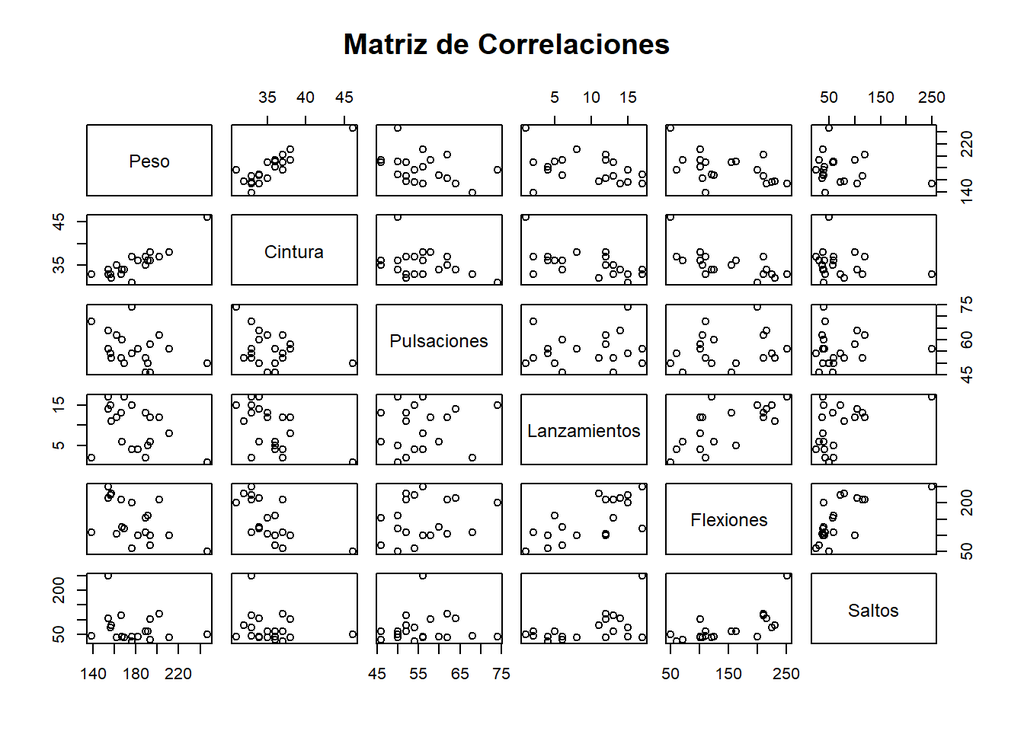

```r
#Matriz de Correlaciones total
plot(data[,1:6], main="Matriz de Correlaciones ")
```

De la matrix de correlacion vemos que las variable con mayor correlacion son:

- Peso - Cintura con r=0.8702435
- Lanzamientos - Flexiones con r=0.6957274
- Flexiones - Saltos con r=0.66920608

De la matrix de correlacion vemos que las variable con menor correlacion son:

- Saltos - Pulsaciones con r=0.03493306
- Lanzamientos - Pulsaciones con r=0.15064802

# Pregunta 4

Hacer un plot de las variables máximamente y mínimamente correladas.

Se graficara primero las relaciones de correlacion maximas las cuales son:

- [1] Peso - Cintura
- [2] Lanzamientos - Flexiones
- [3] Flexiones - Saltos

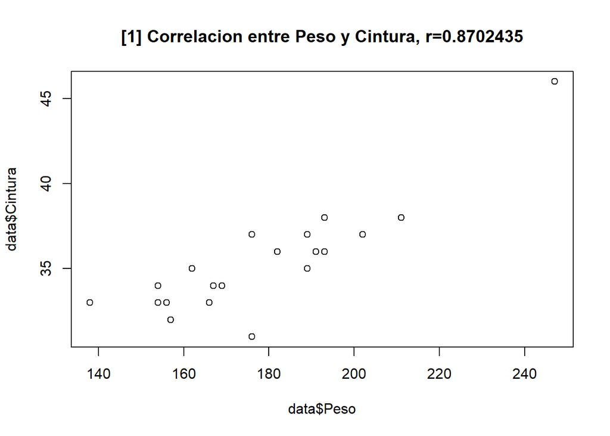

```r
#Correlacion entre Peso y Cintura
plot(data$Peso,data$Cintura,main="[1] Correlacion entre Peso y Cintura, r=0.8702435")
```

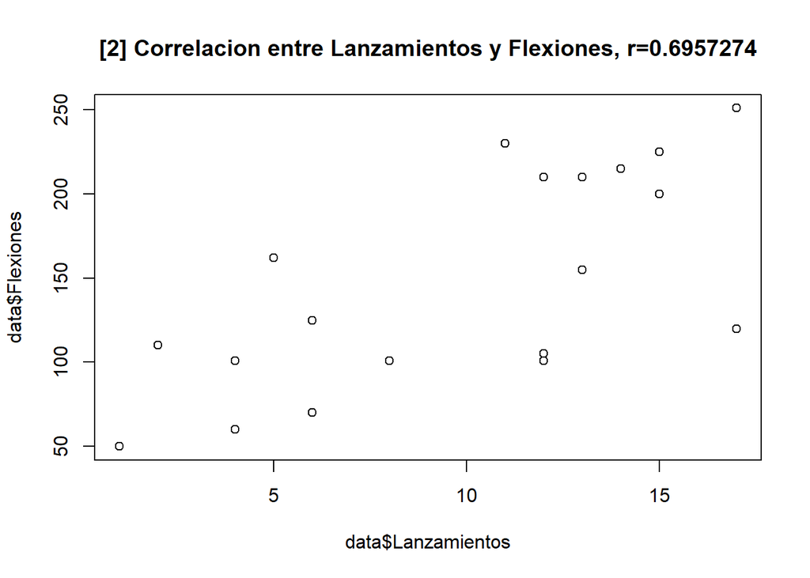

```r
#Correlacion entre Lanzamientos y Flexiones
plot(data$Lanzamientos,data$Flexiones,main="[2] Correlacion entre Lanzamientos y Flexiones, r=0.6957274")
```

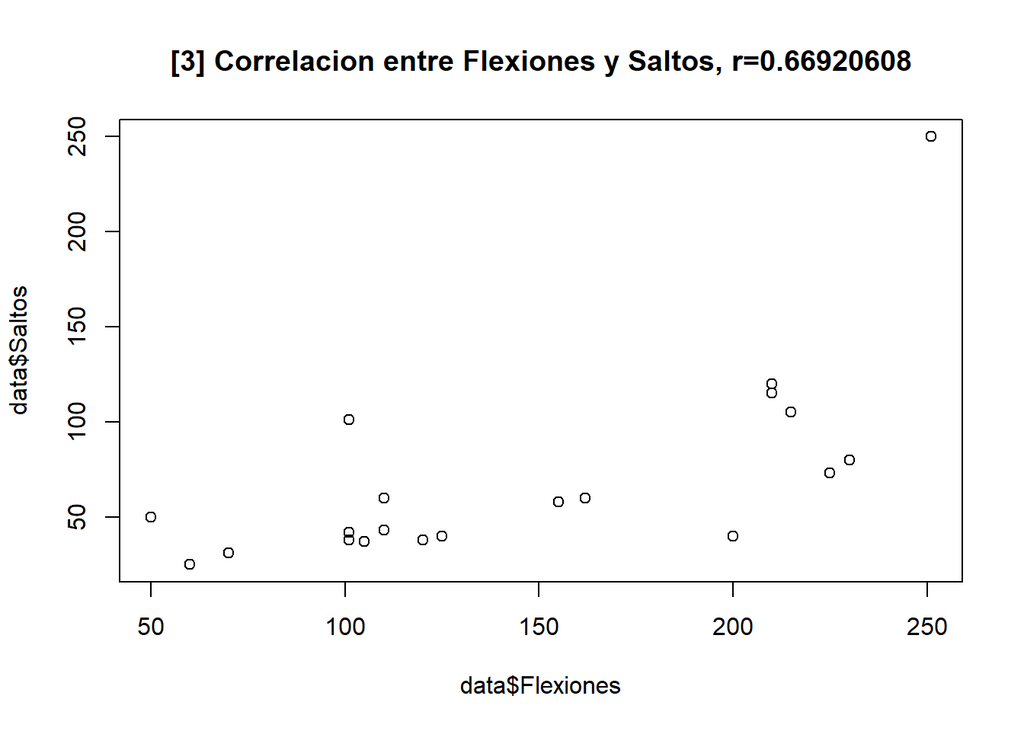

```r
#Correlacion entre Flexiones y Saltos
plot(data$Flexiones,data$Saltos,main="[3] Correlacion entre Flexiones y Saltos, r=0.66920608")
```

- [4] Saltos - Pulsaciones
- [5] Lanzamientos - Pulsaciones

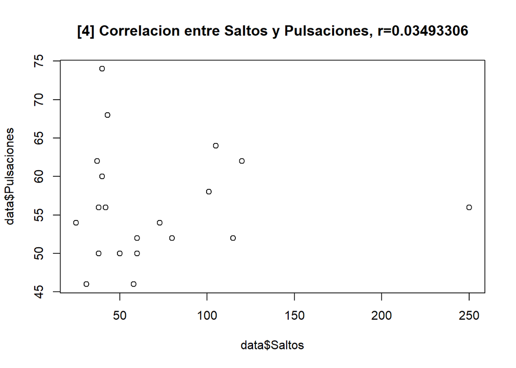

```r
#Correlacion entre Saltos y Pulsaciones
plot(data$Saltos,data$Pulsaciones,main="[4] Correlacion entre Saltos y Pulsaciones, r=0.03493306")
```

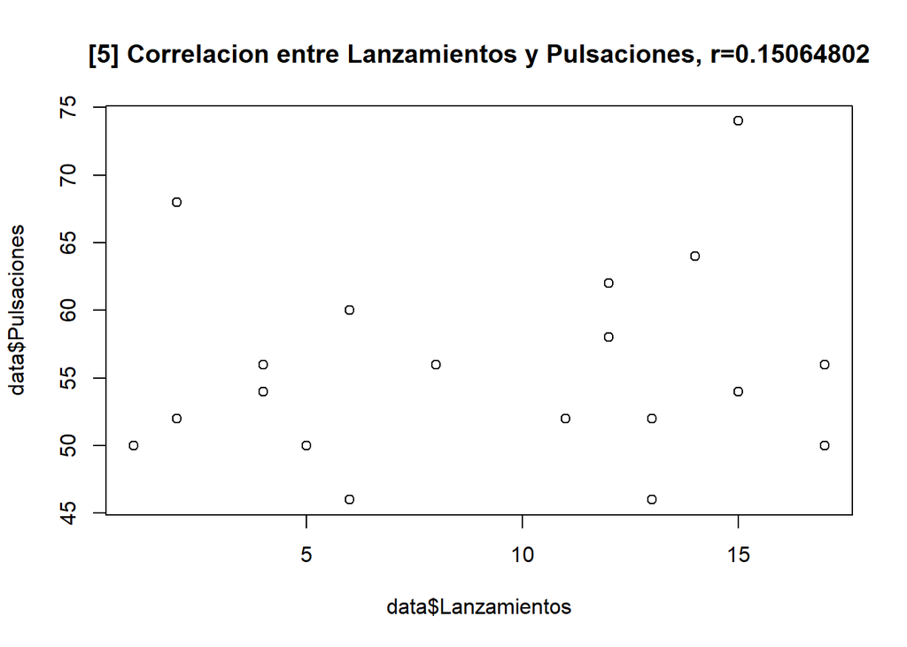

```r
#Correlacion entre Lanzamientos y Pulsaciones
plot(data$Lanzamientos,data$Pulsaciones,main="[5] Correlacion entre Lanzamientos y Pulsaciones, r=0.15064802")
```

# Pregunta 5

Bajar el archivo Marks_Ranks.csv. Tratase de notas de alumnos en Inglés y Matemática y rangos correspondientes. Calcular por cada pareja (Inglés, Matemática) de notas y de rangos las correlaciones de Pearson y de Spearman y comparar.

Se inicia instalando el paquet “rio”, luego de ello se cargara la liberia correpondiente. Se descargara el archivo en una carpeta local, luego de eso leera el archivo en “datos”, para hacer el analisis exploratorio.

```r
# Instalar la biblioteca rio si aún no está instalada
install.packages("rio",repos = "https://cloud.r-project.org/")
```

```r
# Cargar la biblioteca rio
library(rio)
```

```r
# Leer datos desde un archivo Marks_Ranks.csv
datos<- import("G:/R IMCA/TAREA 6/DESCARGA_DATA/Marks_Ranks.csv")
```

```r
# Verificar la estructura de los datos
str(datos)
```

```
## 'data.frame':    10 obs. of  4 variables:
##  $ M_English: int  56 75 45 71 61 64 58 80 76 61
##  $ M_Maths  : int  66 70 40 60 65 56 59 77 67 63
##  $ R_English: num  9 3 10 4 6.5 5 8 1 2 6.5
##  $ R_Maths  : int  4 2 10 7 5 9 8 1 3 6
```

```r
# Visualizar los primeros registros de los datos
head(datos,n=15)
```

|  | M_English | M_Maths | R_English | R_Maths |
| --- | --- | --- | --- | --- |
| 1 | 56 | 66 | 9.0 | 4 |
| 2 | 75 | 70 | 3.0 | 2 |
| 3 | 45 | 40 | 10.0 | 10 |
| 4 | 71 | 60 | 4.0 | 7 |
| 5 | 61 | 65 | 6.5 | 5 |
| 6 | 64 | 56 | 5.0 | 9 |
| 7 | 58 | 59 | 8.0 | 8 |
| 8 | 80 | 77 | 1.0 | 1 |
| 9 | 76 | 67 | 2.0 | 3 |
| 10 | 61 | 63 | 6.5 | 6 |

```r
#Correlacion de Pearson
a<-cor(datos$M_English,datos$M_Maths,method = "pearson")
b<-cor(datos$R_English,datos$R_Maths,method = "pearson")
```

```r
c<-cor(datos$M_English,datos$M_Maths,method ="spearman" )
d<-cor(datos$R_English,datos$R_Maths,method ="spearman")
```

```r
#Inicializcion del dataframe de resultados de las correlaciones
df<-as.data.frame(matrix(0,nrow = 2,  ncol=2))
rownames(df)<-c("( M_English - M_Maths )","( R_English - R_Maths )")
colnames(df)<-c("Pearson","spearman")
df[1,1]<-a
df[2,1]<-b
df[1,2]<-c
df[2,2]<-d
print(df)
```

```
##                           Pearson  spearman
## ( M_English - M_Maths ) 0.8005387 0.6686961
## ( R_English - R_Maths ) 0.6686961 0.6686961
```